# MAT02014 - Planejamento de Experimentos II Experimentos com fatores aleatórios

Rodrigo Citton P. dos Reis `rodrigocpdosreis@gmail.com` Universidade Federal do Rio Grande do Sul Instituto de Matemática e Estatística Departamento de Estatística

Porto Alegre, 2018

# Introdução

## Modelos de efeitos aleatórios

- Quando o objetivo do experimento é estudar a variância na resposta causada pela variação dos níveis de dois fatores independentes, o delineamento é similar ao delineamento fatorial de dois fatores que discutimos anteriormente.
- No entanto, no delineamento apresentado anteriormente, os níveis dos fatores seriam selecionados pelo pesquisador porque este estaria interssado na comparação de respostas médias entre estes níveis.
- Nos modelos de efeitos aleatórios os níveis dos fatores são apenas uma **amostra representativa** ou **aleatória** dos **níveis possíveis**.
  - O objetivo é determinar quanto da variância na resposta pode ser atribuída à variação dos níveis dos fatores.

## Efeitos fixos *vs* efeitos aleatórios

Duas situações:

1. Uma indústria de parafusos adquiriu 5 máquinas de uma determinada marca para produzir parafusos, e está interessada em realizar um experimento para verificar se as 5 máquinas são homogêneas com relação a resistência média dos parafusos por elas produzidos.
2. A indústria de máquinas do exemplo anterior está interessada em realizar um experimento para verificar se as máquinas produzidas por ela são homogêneas com relação à resistência média dos parafusos que estas máquinas irão produzir. Como a população de máquinas produzidas pela indústria é muito grande o pesquisador quer realizar o experimento com uma amostra de máquinas (5, por exemplo), mas a conclusões devem ser estendidas para a população de máquinas.

## Exemplo (Gage R & R)

- *Gage*: **(Gauge?)**, “bitola” ou “medidor”.
- *R & R*: repetibilidade e reprodutibilidade.
- Estudos *Gage R & R* são comuns nos departamentos de qualidade das indústrias.
- Nestes estudos o objetivo é classificar a variabilidade em características medidas de produtos fabricados ou componentes de produtos.
- Assumindo que o medidor, ou o instrumento de medida está devidamente calibrado, um valor medido determinado durante uma inspeção de qualidade pode ser considerado uma função da verdadeira dimensão da característica, a **repetibilidade do medidor**, e a **reprodutibilidade do medidor**.

## Exemplo (Gage R & R)

- A repetibilidade do medidor é a habilidade de um único operador obter o mesmo valor medido múltiplas vezes usando o mesmo instrumento de medida (medidor).
- A reprodutibilidade do medidor é a habilidade de diferentes operadores de obter o mesmo valor medido múltiplas vezes usando o mesmo medidor na mesma *parte*.
  - Se a variabilidade nas medidas causadas pela repetibilidade do medidor mais a reprodutibilidade **é maior que 10% variação tolerada**, as **medições não devem ser precisas (acuradas)** o suficiente para serem usadas no monitoramento da qualidade do produto.

## Exemplo (Gage R & R)

[figure not shown]

## Exemplo (Gage R & R)

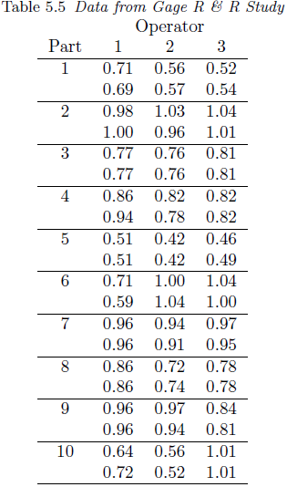

## Exemplo (Gage R & R)

- O estudo Gage R & R consiste na seleção de um conjunto de partes (ou componentes) manufaturadas que são representativas da variabilidade “parte-a-parte” da fabricação normal.
  - No exemplo, 10 partes foram selecionadas e estas partes representam os níveis do primeiro fator no experimento.
- A seguir, uma amostra aleatória ou representativa de inspetores (operadores) é selecionado.
  - Os inspetores representam os níveis do segundo fator no experimento.
- Por fim, cada inspetor mede cada parte duas vezes.

## Exemplo (Gage R & R)

### *Das model*

[figure not shown]

## Exemplo (Gage R & R)

### *Das model*

$$y_{ijk} = \mu + \tau_i + \beta_j + (\tau\beta)_{ij} + \epsilon_{ijk}, i = 1, \ldots, a, j = 1,\ldots, b, k = 1, \ldots, n.$$

## Exemplo (Gage R & R)

### *Das model*

- A **diferença** para o modelo que especificamos para delineamento fatorial de *efeitos fixos* é que assume-se que $\tau_i, \beta_j$ e $(\tau\beta)_{ij}$ são variáveis aleatórias independentes e normalmente distribuídas com médias zero e variâncias $\sigma^2_{\tau}, \sigma^2_{\beta}$ e $\sigma^2_{\tau\beta}$.

$$\Rightarrow Var(y) = \sigma^2_y = \sigma^2_{\tau} + \sigma^2_{\beta} + \sigma^2_{\tau\beta} + \sigma^2$$

## Exemplo (Gage R & R)

### *Das model*

- $\sigma^2_{\tau}$ representa a porção da variância total devida a diferenças nas partes.
- $\sigma^2_{\beta}$ é a porção da variância causada pelas diferenças entre operadores.
- $\sigma^2_{\tau\beta}$ é a porção da variância causada pela interação operador e parte.
- $\sigma^2$ é a porção da variância causada pela medidas replicadas ou **repetibilidade do medidor**.
- A soma $\sigma^2_{\beta} + \sigma^2_{\tau\beta}$ é a reprodutibilidade do medidor.
- A repetibilidade mais a reprodutibilidade, $\sigma^2_{\beta} + \sigma^2_{\tau\beta} + \sigma^2$, é uma medida da variância atribuível ao erro de medição.

## Estimando os componentes de variância

- Para o caso com número igual de replicações por subclasse é conveniente usar o **método dos momentos** ou **máxima verossimilhança restrita** (REML).

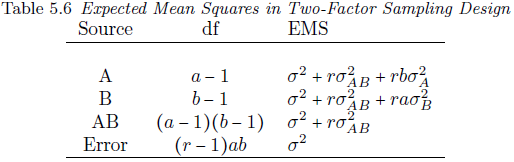

## Estimando os componentes de variância

```r
library(daewr)
head(gagerr)
```

```
##   part oper    y
## 1    1    1 0.71
## 2    1    1 0.69
## 3    1    2 0.56
## 4    1    2 0.57
## 5    1    3 0.52
## 6    1    3 0.54
```

## Estimando os componentes de variância

```r
modr1 <- aov( y ~ part + oper + part:oper,
              data = gagerr)
summary(modr1)
```

```
##             Df Sum Sq Mean Sq F value   Pr(>F)
## part         9 1.4489 0.16099  214.18  < 2e-16 ***
## oper         2 0.0297 0.01485   19.76 3.35e-06 ***
## part:oper   18 0.4839 0.02689   35.77 1.87e-15 ***
## Residuals   30 0.0225 0.00075
## ---
## Signif. codes:  0 '***' 0.001 '**' 0.01 '*' 0.05 '.' 0.1 ' ' 1
```

## Estimando os componentes de variância

### Método dos momentos

```r
sigma2 <- .000752
sigma2po <- (0.026885 - sigma2) / 2
sigma2o <- (0.014852 - sigma2 - 2 * sigma2po ) / 20
sigma2p <- (.160991 - sigma2 - 2 * sigma2po ) / 6
cat("Method of Moments Variance Component Estimates","\n",
    "Var(error)=",sigma2,"\n","Var(part x oper)=",sigma2po,"\n",
    "Var(oper)=",sigma2o,"\n","Var(part)=",sigma2p,"\n")
```

```
## Method of Moments Variance Component Estimates
##  Var(error)= 0.000752
##  Var(part x oper)= 0.0130665
##  Var(oper)= -0.00060165
##  Var(part)= 0.022351
```

## Estimando os componentes de variância

```r
library(lme4)
modr2 <- lmer(y ~ 1 + (1|part) + (1|oper) + (1|part:oper),
              data = gagerr)
summary(modr2)
```

```
## Linear mixed model fit by REML ['lmerMod']
## Formula: y ~ 1 + (1 | part) + (1 | oper) + (1 | part:oper)
##    Data: gagerr
##
## REML criterion at convergence: -133.9
##
## Scaled residuals:
##      Min       1Q   Median       3Q      Max
## -2.43502 -0.36558 -0.01169  0.38978  1.94190
##
## Random effects:
##  Groups    Name        Variance  Std.Dev.
##  part:oper (Intercept) 0.0124650 0.11165
##  part      (Intercept) 0.0225515 0.15017
##  oper      (Intercept) 0.0000000 0.00000
##  Residual              0.0007517 0.02742
## Number of obs: 60, groups:  part:oper, 30; part, 10; oper, 3
##
## Fixed effects:
##             Estimate Std. Error t value
## (Intercept)   0.7982     0.0518   15.41
```

## Estimando os componentes de variância

### Exemplo (Gage R & R)

- Dos resultados, podemos ver que $94.3\% = 100 \times [0.01247/(0.01247 + 0.0007517)]$ do erro de medição é devido a reprodutibilidade.
- Assim, para **reduzir** o erro de medição, os esforços devem se concentrar em treinamentos para os operadores ao invés de investir em medidores (*gages*) mais precisos.

## Para casa (para aula)

- Discuta outras aplicações que você considera que o delineamento de fatores aleatórios é apropriado.